# Análise de vendas

ROSNA ALVES

Os dados para estas análises foram coletados da fonte:

KAGGLE. Sales of summer clothes in E-commerce wishi, 2021. Disponível em: URL. Acesso em: <https://www.kaggle.com/jmmvutu/summer-products-and-sales-in-ecommerce-wish > 31 de julho de 2021.

O presente arquivo apresenta resultados referentes a produtos relacionados ao verão na Europa. Estes foram disponíveis para venda a partir de julho de 2020, na plataforma de comércio eletrônico Wish.com .

“Wish oferece uma experiência de compra baseada em descoberta que reflete como os consumidores compram há anos em lojas físicas. Por meio de uma maior interação, nossa tecnologia consegue conhecer nossos usuários e seleciona um feed de produto personalizado para eles. Nossos comerciantes estão continuamente expandindo sua seleção de produtos para fornecer produtos mais diversificados a preços altamente competitivos. Peter Szulczewski acredita piamente na tecnologia que melhora a vida das pessoas quando e onde for aplicável. Como ex-engenheiro do Google, Szulczewski passou seis anos e meio desenvolvendo a tecnologia principal que alimenta o Google AdWords e a pesquisa na web. Em 2010, ele fundou a Wish para ajudar os consumidores que foram deixados para trás pelas ofertas de comércio eletrônico tradicionais.”

WISH. Wish, 2021. Disponível em: URL. Acesso em: <https://www.wish.com/companyinfo > 30 de julho de 2021.

Este estudo foi feito com o intuito de responder as perguntas a seguir:

### 1. O preço influencia na quantidade de vendas?

A hipótese testade é de que a redução dos preços influencia na quantidade de produtos vendidos, ou seja, quanto maior o desconto mais vendas.

Antes de tudo, foi interessante, classificar os descontos por tipos, para compará-los:

0% equivale a nenhum desconto (ND)

De 1% a 30% desconto baixo (DB)

De 31% a 50% desconto médio (DM)

Maior que 50% desconto alto (DA)

```r
difpr = c(price - retail_price) # Diferença entre o preço vendido pelo preço de referência.
difpr = -difpr # Deixando os valores positivos
porcVal = (difpr/retail_price)*100 # Calculando a porcetagem de desconto em relação ao valor referencia do produto.
#
# CLASSIFICANDO OS DESCONTOS:
#
n=length(porcVal)
clasd = c()
for( i in 1:n){
  if(porcVal[i] == 0){ clasd[i] <- "ND"}
  else if(porcVal[i] > 0 & porcVal[i] < 30){clasd[i] <- "DB"}
   else if(porcVal[i] > 30 & porcVal[i] < 50){clasd[i] <- "DM"      }     else{clasd[i] <- "DA"}
}

novosummer = data.frame(summer,difpr,porcVal,clasd) # conjunto de dados com todas as variáveis criadas.

nproduct=nrow(distinct(novosummer, product_id)) # verificando se há repetição do ID de produto.

# Existem linhas duplicadas no conjunto de dados que podem enviesar o resultados. Essas linhas serão retiradas com o comando: #

novosummer =  novosummer%>%
  distinct(product_id, .keep_all = TRUE)# Retirando linhas duplicadas.
```

#### Resultados para produtos sem desconto (ND)

```r
ND = novosummer %>%
  filter(clasd == "ND")

# units_sold é o número de unidades vendidas.
table(ND$units_sold) # Soma quantos produtos tiveram a mesma quantidade de vendas.
```

```
##
##     1     2     3    10    50   100  1000  5000 10000 20000 50000
##     1     1     1     6     4    41    42    28    18    11     4
```

```r
prop.table(table(ND$units_sold)) # proporção representada por cada grupo.
```

```
##
##           1           2           3          10          50         100
## 0.006369427 0.006369427 0.006369427 0.038216561 0.025477707 0.261146497
##        1000        5000       10000       20000       50000
## 0.267515924 0.178343949 0.114649682 0.070063694 0.025477707
```

```r
# média de vendas por pruduto
median(ND$units_sold)
```

```
## [1] 1000
```

De 157 produtos que não apresentaram descontos, 2,5% venderam 50000 unidades. E de acordo com o mediana, 50% dos produtos venderam até 1000 unidades.

#### Resultados para produtos com desconto baixo (DB)

```r
DB = novosummer %>%
  filter(clasd == "DB")
D=DB
table(D$units_sold)
```

```
##
##     7    10    50   100  1000  5000 10000 20000
##     1     3     8    53    40    14    25    10
```

```r
prop.table(table(D$units_sold))
```

```
##
##           7          10          50         100        1000        5000
## 0.006493506 0.019480519 0.051948052 0.344155844 0.259740260 0.090909091
##       10000       20000
## 0.162337662 0.064935065
```

```r
median(D$units_sold)
```

```
## [1] 1000
```

De acordo com a mediana, 50% do produtos tiveram até 1000 unidades vendidas.

#### Resultados para produtos desconto médio (DM)

```r
DM = novosummer %>%
  filter(clasd == "DM")
D=DM
table(D$units_sold)
```

```
##
##    10    50   100  1000  5000 10000 20000 50000
##     1     3    22    25     8     9     7     2
```

```r
prop.table(table(D$units_sold))
```

```
##
##         10         50        100       1000       5000      10000      20000
## 0.01298701 0.03896104 0.28571429 0.32467532 0.10389610 0.11688312 0.09090909
##      50000
## 0.02597403
```

```r
mean(D$units_sold)
```

```
## [1] 5160.519
```

```r
median(D$units_sold)
```

```
## [1] 1000
```

De acordo com a mediana 50% dos produtos tiveram até 1000 unidades vendidas.

#### Resultados para produtos com desconto alto (DA)

```r
DA = novosummer %>%
  filter(clasd == "DA")
D=DA
table(D$units_sold)
```

```
##
##     1     2     3     6     7     8    10    50   100  1000  5000 10000 20000
##     2     1     1     1     1     2    26    35   280   255   150   111    71
## 50000 1e+05
##    11     6
```

```r
prop.table(table(D$units_sold))
```

```
##
##           1           2           3           6           7           8
## 0.002098636 0.001049318 0.001049318 0.001049318 0.001049318 0.002098636
##          10          50         100        1000        5000       10000
## 0.027282267 0.036726128 0.293809024 0.267576076 0.157397692 0.116474292
##       20000       50000       1e+05
## 0.074501574 0.011542497 0.006295908
```

```r
median(D$units_sold)
```

```
## [1] 1000
```

29% dos produtos com desconto alto tiveram 100 unidades vendidas.

De acordo com a mediana, 50% do produtos tiveram até 1000 unidades vendidas.

#### Comparando

Uma forma de comparar os grupos é aplicar o teste de Kruskal-Wallis (teste não-paramétrico), que tem como requisito apenas a independência entre os grupos. Ele vai dizer se os grupos apresentam comportamentos semelhantes.

fixando un nível de significância (que é até quanto é permitido errar) igual a 0,05 (Isso quer dizer que determina-se 95% de confiança na tomada de decisão) temos:

```r
kruskal.test(novosummer$units_sold,novosummer$clasd)
```

```
##
##  Kruskal-Wallis rank sum test
##
## data:  novosummer$units_sold and novosummer$clasd
## Kruskal-Wallis chi-squared = 1.7457, df = 3, p-value = 0.6268
```

Como p-valor > 0,05, então podemos dizer que há evidências estatísticas de que os grupos apresentam comportamentos semelhantes em relação a mediana. Isso quer dizer que o tamanho do desconto não teve influência significativa sobre a quantidade de produtos vendidos.

### 2. Produtos que mais venderam e suas classificações.

Nesse conjunto de dados, o número de classificações, em alguns casos, é maior do que o número de unidades vendidas. Talvez, o site possa ter sumarizando as classificações de vendas anteriores ao mês das que foram estudadas. Por isso, estas análises foram feitas, usando o valor total de classificações, e não o total de unidades vendidas por produto.

Primeiramente, foi calculada a proporção de cada classificação, em relação ao total de classificações por produtos, e essas informações foram representadas nos gráficos a seguir:

```r
# Quantidade de produtos por quantidade de vendas
table(novosummer$units_sold)
```

```
##
##     1     2     3     6     7     8    10    50   100  1000  5000 10000 20000
##     3     2     2     1     2     2    36    50   396   362   200   163    99
## 50000 1e+05
##    17     6
```

Essa tabela de dados mostra que 3 produtos venderam apenas 1 unidade, 2 produtos venderam apenas 2 unidades, e assim por diante.

Focando naqueles que venderam mais unidades, temos sete grupos de produtos:

#### Produtos que venderam 100 unidades

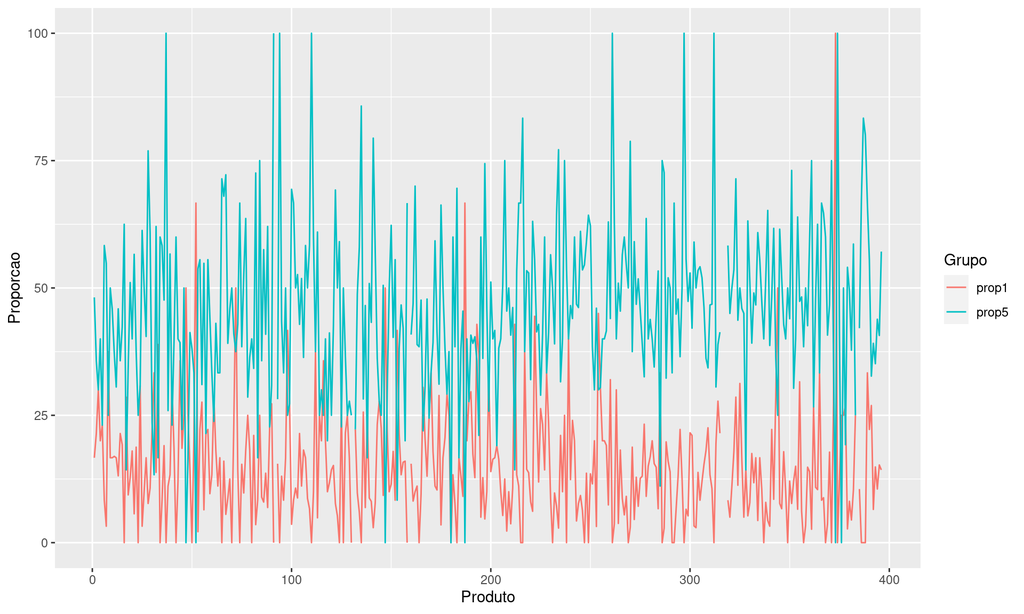

```r
# Dos produtos que venderam 100 unidades temos:
cem_units=novosummer%>%
  filter(units_sold == 100)

classifica=cem_units%>%
  select(product_id, rating_count,rating_one_count, rating_two_count, rating_three_count, rating_four_count, rating_five_count)
product_id=classifica$product_id

  prop1=classifica$rating_one_count/classifica$rating_count*100 # Proporção dos classificados com 1 estrela
  prop2=classifica$rating_two_count/classifica$rating_count*100 # Proporção dos classificados com 2 estrela
  prop3=classifica$rating_three_count/classifica$rating_count*100 # Proporção dos classificados com 3 estrela
  prop4=classifica$rating_four_count/classifica$rating_count*100 # Proporção dos classificados com 4 estrela
  prop5=classifica$rating_five_count/classifica$rating_count*100 # Proporção dos classificados com 5 estrela

  #data.frame(product_id,prop1,prop2,prop3,prop4,prop5)

#---- Gráfico
x=rep(1:(length(classifica$product_id)))
valor = c(prop1,prop5)
Grupo = c(rep("prop1",length(x)),rep("prop5", length(x)))

dados=data.frame(Produto = rep(x,2),
                 Proporcao = valor,
                 Grupo = Grupo)
ggplot(dados, aes(x=Produto, y = Proporcao, Grupo = Grupo))+geom_line(aes(colour = Grupo, lintype = Grupo))
```

A variável prop5 representa a porcentagem de classificações de 5 estrelas (Maior classificação) de cada produto. Essa, foi a que mais se destacou. Isso quer dizer, que os produtos que tiveram 100 unidades vendidas tiveram mais marcações com 5 estrelas do que as demais marcações.

#### Produtos que venderam 1000 unidades

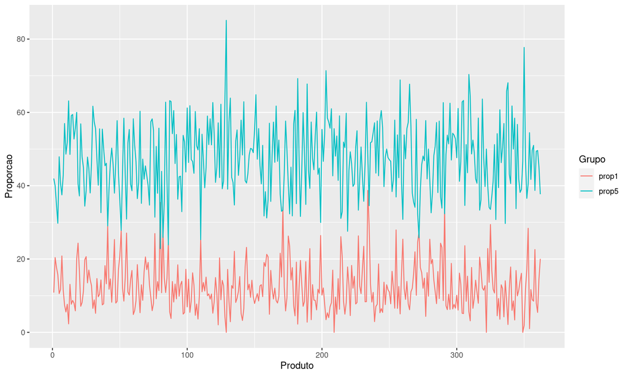

```r
# Dos produtos que venderam 10000 unidades temos:

cem_units=novosummer%>%
  filter(units_sold == 1000)

classifica=cem_units%>%
  select(product_id, rating_count,rating_one_count, rating_two_count, rating_three_count, rating_four_count, rating_five_count)
product_id=classifica$product_id

  prop1=classifica$rating_one_count/classifica$rating_count*100
  prop2=classifica$rating_two_count/classifica$rating_count*100
  prop3=classifica$rating_three_count/classifica$rating_count*100
  prop4=classifica$rating_four_count/classifica$rating_count*100
  prop5=classifica$rating_five_count/classifica$rating_count*100
  #data.frame(product_id,prop1,prop2,prop3,prop4,prop5)
#---- Gráfico
x=rep(1:(length(classifica$product_id)))
valor = c(prop1,prop5)
Grupo = c(rep("prop1",length(x)),rep("prop5", length(x)))

dados=data.frame(Produto = rep(x,2),
                 Proporcao = valor,
                 Grupo = Grupo)
ggplot(dados, aes(x=Produto, y = Proporcao, Grupo = Grupo))+geom_line(aes(colour = Grupo, lintype = Grupo))
```

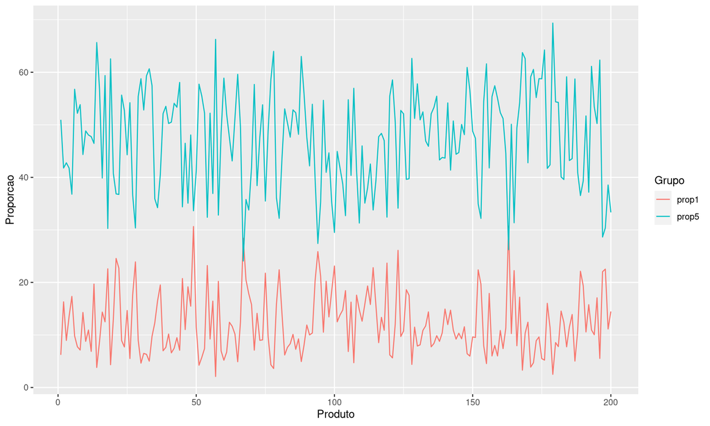

```r
# Dos produtos que venderam 50 000 unidades temos:

cem_units=novosummer%>%
  filter(units_sold == 5000)

classifica=cem_units%>%
  select(product_id, rating_count,rating_one_count, rating_two_count, rating_three_count, rating_four_count, rating_five_count)
product_id=classifica$product_id

  prop1=classifica$rating_one_count/classifica$rating_count*100
  prop2=classifica$rating_two_count/classifica$rating_count*100
  prop3=classifica$rating_three_count/classifica$rating_count*100
  prop4=classifica$rating_four_count/classifica$rating_count*100
  prop5=classifica$rating_five_count/classifica$rating_count*100
  #data.frame(product_id,prop1,prop2,prop3,prop4,prop5)
#---- Gráfico
x=rep(1:(length(classifica$product_id)))
valor = c(prop1,prop5)
Grupo = c(rep("prop1",length(x)),rep("prop5", length(x)))

dados=data.frame(Produto = rep(x,2),
                 Proporcao = valor,
                 Grupo = Grupo)
ggplot(dados, aes(x=Produto, y = Proporcao, Grupo = Grupo))+geom_line(aes(colour = Grupo, lintype = Grupo))
```

#### Produtos que venderam 10 000 unidades

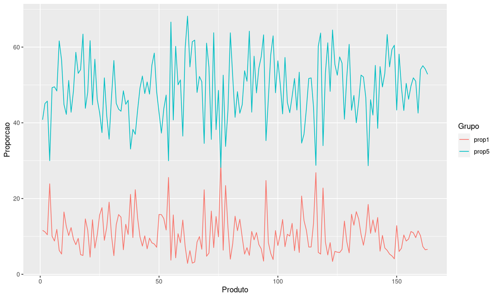

```r
# Dos produtos que venderam 10 000 unidades temos:

cem_units=novosummer%>%
  filter(units_sold == 10000)

classifica=cem_units%>%
  select(product_id, rating_count,rating_one_count, rating_two_count, rating_three_count, rating_four_count, rating_five_count)
product_id=classifica$product_id

  prop1=classifica$rating_one_count/classifica$rating_count*100
  prop2=classifica$rating_two_count/classifica$rating_count*100
  prop3=classifica$rating_three_count/classifica$rating_count*100
  prop4=classifica$rating_four_count/classifica$rating_count*100
  prop5=classifica$rating_five_count/classifica$rating_count*100
  #data.frame(product_id,prop1,prop2,prop3,prop4,prop5)
#---- Gráfico
x=rep(1:(length(classifica$product_id)))
valor = c(prop1,prop5)
Grupo = c(rep("prop1",length(x)),rep("prop5", length(x)))

dados=data.frame(Produto = rep(x,2),
                 Proporcao = valor,
                 Grupo = Grupo)
ggplot(dados, aes(x=Produto, y = Proporcao, Grupo = Grupo))+geom_line(aes(colour = Grupo, lintype = Grupo))
```

#### Produtos que venderam 20 000 unidades

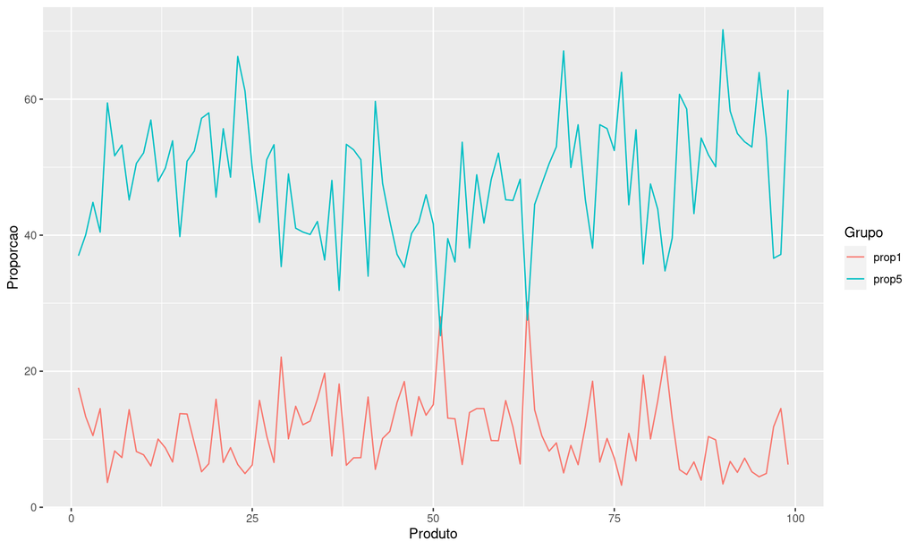

```r
# Dos produtos que venderam 20 000 unidades temos:

cem_units=novosummer%>%
  filter(units_sold == 20000)

classifica=cem_units%>%
  select(product_id, rating_count,rating_one_count, rating_two_count, rating_three_count, rating_four_count, rating_five_count)
product_id=classifica$product_id

  prop1=classifica$rating_one_count/classifica$rating_count*100
  prop2=classifica$rating_two_count/classifica$rating_count*100
  prop3=classifica$rating_three_count/classifica$rating_count*100
  prop4=classifica$rating_four_count/classifica$rating_count*100
  prop5=classifica$rating_five_count/classifica$rating_count*100
  #data.frame(product_id,prop1,prop2,prop3,prop4,prop5)
#---- Gráfico
x=rep(1:(length(classifica$product_id)))
valor = c(prop1,prop5)
Grupo = c(rep("prop1",length(x)),rep("prop5", length(x)))

dados=data.frame(Produto = rep(x,2),
                 Proporcao = valor,
                 Grupo = Grupo)
ggplot(dados, aes(x=Produto, y = Proporcao, Grupo = Grupo))+geom_line(aes(colour = Grupo, lintype = Grupo))
```

#### Produtos que venderam 50 000 unidades

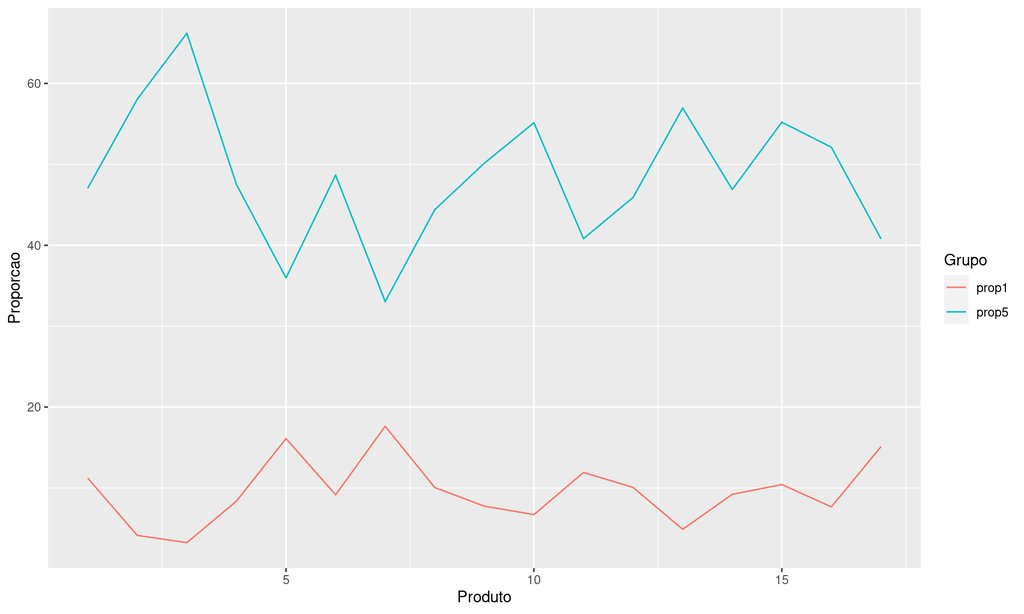

```r
# Dos produtos que venderam 50 000 unidades temos:

cem_units=novosummer%>%
  filter(units_sold == 50000)

classifica=cem_units%>%
  select(product_id, rating_count,rating_one_count, rating_two_count, rating_three_count, rating_four_count, rating_five_count)
product_id=classifica$product_id

  prop1=classifica$rating_one_count/classifica$rating_count*100
  prop2=classifica$rating_two_count/classifica$rating_count*100
  prop3=classifica$rating_three_count/classifica$rating_count*100
  prop4=classifica$rating_four_count/classifica$rating_count*100
  prop5=classifica$rating_five_count/classifica$rating_count*100
  #data.frame(product_id,prop1,prop2,prop3,prop4,prop5)
#---- Gráfico
x=rep(1:(length(classifica$product_id)))
valor = c(prop1,prop5)
Grupo = c(rep("prop1",length(x)),rep("prop5", length(x)))

dados=data.frame(Produto = rep(x,2),
                 Proporcao = valor,
                 Grupo = Grupo)
ggplot(dados, aes(x=Produto, y = Proporcao, Grupo = Grupo))+geom_line(aes(colour = Grupo, lintype = Grupo))
```

#### Produtos que venderam 100 000 unidades

```r
# Dos produtos que venderam 100 000 unidades temos:

cem_units=novosummer%>%
  filter(units_sold == 100000)

classifica=cem_units%>%
  select(product_id, rating_count,rating_one_count, rating_two_count, rating_three_count, rating_four_count, rating_five_count)
product_id=classifica$product_id

  prop1=classifica$rating_one_count/classifica$rating_count*100
  prop2=classifica$rating_two_count/classifica$rating_count*100
  prop3=classifica$rating_three_count/classifica$rating_count*100
  prop4=classifica$rating_four_count/classifica$rating_count*100
  prop5=classifica$rating_five_count/classifica$rating_count*100
  data.frame(product_id,prop1,prop2,prop3,prop4,prop5)
```

```
##                 product_id     prop1     prop2    prop3    prop4    prop5
## 1 5b07a7c6e997b33c6f9947da 10.266963  7.842047 16.41268 19.37152 46.10679
## 2 544b079d1280fa28eee9b380  6.339182  5.659468 14.07154 20.01543 53.91438
## 3 54bdf18039b8c045f118936a 11.489785  7.611643 16.88664 21.85862 42.15332
## 4 53897eeeafddf70c91af1cda  7.680035  6.534194 15.45435 20.56712 49.76430
## 5 567cb0925ff12c4829f07dfb 10.022664  8.058424 16.57013 20.39788 44.95089
## 6 571adeab62cce546f1a46bc0 13.912902 10.890013 19.88800 18.50704 36.80204
```

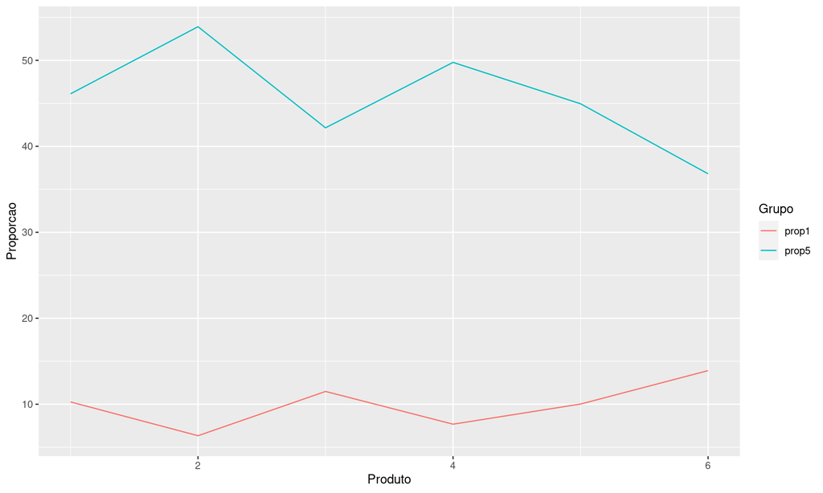

```r
  #table_pro10000=data.frame(product_id,prop1,prop2,prop3,prop4,prop5)
#---- Gráfico
x=rep(1:(length(classifica$product_id)))
valor = c(prop1,prop5)
Grupo = c(rep("prop1",length(x)),rep("prop5", length(x)))

dados=data.frame(Produto = rep(x,2),
                 Proporcao = valor,
                 Grupo = Grupo)
ggplot(dados, aes(x=Produto, y = Proporcao, Grupo = Grupo))+geom_line(aes(colour = Grupo, lintype = Grupo))
```

Os produtos que tiveram menos quantidades vendidas não apresentaram informações suficientes para fazer estas analises, isso indica que a maior parte dos compradores não opinou sobre o produto.

### Estudos futuros

O próximo passo para estas análises, será construir um modelo de predição de quantidade de vendas, conseguindo identificar quais variáveis as influenciam significativamente. Para isso, será interessante ter mais informações com relação ao meses anteriores.